# SVM model using Count Vectors for Unigram+Bigram

| Team Member | Contribution |
| --- | --- |
| Mayisha Nazar | Import Libraries and Modules |
|  | Load the Dataset |
|  | Map Star Ratings to Sentiment Categories |
|  | Data Preprocessing |
|  | Handle Missing Data and Select Relevant Columns |
|  | Split the Dataset into Training and Testing Sets |
|  | Feature Extraction with CountVectorizer |
|  | Support Vector Machine (SVM) Model Training |
|  | Model Training Time Measurement |
|  | Model Prediction and Decision Scores,LIME |
| Tirth Patel | Model Evaluation |
|  | Confusion Matrix |
|  | AUC and ROC Curve |
|  | Training and Testing Metrics |
|  | Accuracy Evaluation |
|  | Extract and Display F1 Scores for Sentiment Categories |
|  | Stratified K-Fold Cross-Validation |
|  | Grid Search for Hyperparameter Tuning |
|  | Extract Top Features Contributing to Sentiment |
|  | Review Length Analysis |

prompt for your SVM model using Count Vectors for Unigram+Bigram: 1. Clean the Yelp dataset by converting text to lowercase, removing punctuation, stopwords, and digits before building the SVM model using Count Vectors for Unigram+Bigram. 2. Build an SVM model using Count Vectors for Unigram+Bigram to predict if a review is Positive, Negative, or Neutral based on star ratings. 3. Handle the class imbalance issue in the dataset and improve the performance of the SVM model. 4. Evaluate the model using F1 scores for each sentiment category (Positive, Negative, Neutral) and suggest improvements. 5. Experiment with other techniques (e.g., oversampling, class weights) to address class imbalance and boost performance. Assistance was sought from ChatGPT in refining the approach.

Config of the model trained

AUC plotted - yes AUC = 0.8432787061178543

Accuracy computed - yes Accuracy = 0.79

Feature Engg Categorical/Numerical Features Added - yes

Name 2 features added - review_length, sentiment

Cross Validation - yes

Interpretability Interpretability Implemented? - yes

2 interesting findings?

Testing Data Check

```python
import pandas as pd
import numpy as np
import re
from sklearn.model_selection import cross_val_score, StratifiedKFold
from lime.lime_text import LimeTextExplainer
from sklearn.model_selection import GridSearchCV
from sklearn.model_selection import train_test_split
from sklearn.feature_extraction.text import CountVectorizer
from sklearn.svm import SVC
from sklearn.metrics import classification_report, confusion_matrix, roc_auc_score, roc_curve, accuracy_score
from nltk.corpus import stopwords
from nltk.stem import WordNetLemmatizer
import matplotlib.pyplot as plt
import seaborn as sns
import time
```

```python
# Load the dataset
df = pd.read_csv('yelp_sample_20k.csv')
```

```python
df
```

|  | text | stars |
| --- | --- | --- |
| 0 | We really enjoyed their use of homemade ingred... | 5.0 |
| 1 | We moved to Sarasota and upon many recommendat... | 5.0 |
| 2 | Very disappointed in today's meal. The wife an... | 2.0 |
| 3 | I wish I could reward the store w 5 stars, pro... | 4.0 |
| 4 | Came here for brunch yesterday, it goes till 3... | 5.0 |
| ... | ... | ... |
| 19995 | One of the worst before dinner experiences I h... | 1.0 |
| 19996 | This place is magical. It's perfect for weddin... | 5.0 |
| 19997 | to the person that hit my brand new car yester... | 2.0 |
| 19998 | Lilly's is one of the best places to go for lu... | 5.0 |
| 19999 | I didn't think it'd happen, but I've finally f... | 4.0 |

20000 rows × 2 columns

```python
# Map star ratings to sentiment categories
def assign_sentiment(stars):
    if stars >= 4:
        return 'Positive'
    elif stars <= 2:
        return 'Negative'
    else:
        return 'Neutral'

df['Sentiment'] = df['stars'].apply(assign_sentiment)
```

```python
df.shape
```

```
(20000, 3)
```

```python
df.head()
```

|  | text | stars | Sentiment |
| --- | --- | --- | --- |
| 0 | We really enjoyed their use of homemade ingred... | 5.0 | Positive |
| 1 | We moved to Sarasota and upon many recommendat... | 5.0 | Positive |
| 2 | Very disappointed in today's meal. The wife an... | 2.0 | Negative |
| 3 | I wish I could reward the store w 5 stars, pro... | 4.0 | Positive |
| 4 | Came here for brunch yesterday, it goes till 3... | 5.0 | Positive |

```python
# Preprocessing: Convert text to lowercase, remove stopwords, punctuations, digits, and apply lemmatization
stop_words = set(stopwords.words('english'))
lemmatizer = WordNetLemmatizer()

def preprocess_text(text):
    text = text.lower()
    text = re.sub(r'\d+', '', text)  # Remove digits
    text = re.sub(r'[^\w\s]', '', text)  # Remove punctuations
    tokens = text.split() #tokenization
    tokens = [word for word in tokens if word not in stop_words]
    tokens = [lemmatizer.lemmatize(word) for word in tokens] #lemmatization
    return ' '.join(tokens)

df['cleaned_text'] = df['text'].apply(preprocess_text)
```

```python
# Drop unnecessary columns and handle missing values
df = df[['cleaned_text','stars','Sentiment']].dropna()
```

```python
df.head()
```

|  | cleaned_text | stars | Sentiment |
| --- | --- | --- | --- |
| 0 | really enjoyed use homemade ingredient really ... | 5.0 | Positive |
| 1 | moved sarasota upon many recommendation decide... | 5.0 | Positive |
| 2 | disappointed today meal wife got pasta dish wa... | 2.0 | Negative |
| 3 | wish could reward store w star product marketi... | 4.0 | Positive |
| 4 | came brunch yesterday go till pm great late ri... | 5.0 | Positive |

```python
# Split the dataset
X = df['cleaned_text']
y = df['Sentiment'] #target
X_train, X_test, y_train, y_test = train_test_split(X, y, test_size=0.3, random_state=42, stratify=y)
```

```python
# Feature extraction using Count Vectors for Unigram+Bigram with max_features
count_vectorizer = CountVectorizer(ngram_range=(1, 2), stop_words='english', max_features=5000)  # Select top 5000 features
X_train_cv = count_vectorizer.fit_transform(X_train)
X_test_cv = count_vectorizer.transform(X_test)
```

```python
# SVM using Count Vectors for Unigram+Bigram
svm_model = SVC(kernel='linear', probability=True)
svm_model.fit(X_train_cv, y_train)
svm_preds = svm_model.predict(X_test_cv)
svm_probs = svm_model.decision_function(X_test_cv)
```

```python
# Train the SVM model with default parameters
start_time = time.time()
svm_model = SVC(kernel='linear', probability=True)
svm_model.fit(X_train_cv, y_train)
end_time = time.time()

training_time = end_time - start_time
print(f"Training Time: {training_time:.2f} seconds")
```

```
Training Time: 346.27 seconds
```

```python
# Predictions and decision scores
svm_preds = svm_model.predict(X_test_cv)
svm_probs = svm_model.decision_function(X_test_cv)
```

```python
# Evaluation Metrics
print("SVM with Unigram+Bigram (Count Vectors):\n", classification_report(y_test, svm_preds))
```

```
SVM with Unigram+Bigram (Count Vectors):
               precision    recall  f1-score   support

    Negative       0.72      0.78      0.75      1380
     Neutral       0.28      0.27      0.28       565
    Positive       0.90      0.88      0.89      4055

    accuracy                           0.80      6000
   macro avg       0.63      0.64      0.64      6000
weighted avg       0.80      0.80      0.80      6000
```

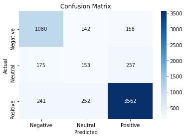

```python
# Confusion Matrix
conf_matrix = confusion_matrix(y_test, svm_preds)
sns.heatmap(conf_matrix, annot=True, fmt='d', cmap='Blues', xticklabels=svm_model.classes_, yticklabels=svm_model.classes_)
plt.title("Confusion Matrix")
plt.xlabel("Predicted")
plt.ylabel("Actual")
plt.show()
```

```
AUC: 0.8432787061178543
```

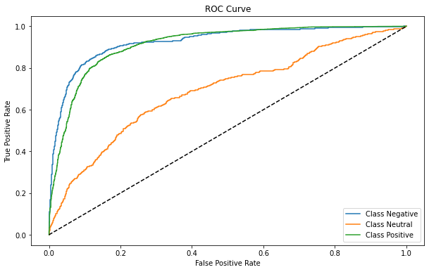

```python
# AUC and ROC Curve
auc = roc_auc_score(pd.get_dummies(y_test).values, svm_probs, multi_class='ovr')
print("AUC:", auc)

fpr = {}
tpr = {}
thresh = {}
classes = svm_model.classes_
plt.figure(figsize=(10, 6))
for i, class_label in enumerate(classes):
    fpr[class_label], tpr[class_label], thresh[class_label] = roc_curve((y_test == class_label).astype(int), svm_probs[:, i])
    plt.plot(fpr[class_label], tpr[class_label], label=f"Class {class_label}")
plt.plot([0, 1], [0, 1], 'k--')
plt.xlabel("False Positive Rate")
plt.ylabel("True Positive Rate")
plt.title("ROC Curve")
plt.legend()
plt.show()
```

```python
from sklearn.metrics import f1_score
# Measure train time
start_train_time = time.time()
svm_model.fit(X_train_cv, y_train)
train_time = time.time() - start_train_time

# Predictions on training data
y_train_pred = svm_model.predict(X_train_cv)

# Predictions on testing data
start_test_time = time.time()
y_test_pred = svm_model.predict(X_test_cv)
test_time = time.time() - start_test_time

# Train Data Metrics
print("=== Training Data Metrics ===")
print("Confusion Matrix (Train):")
print(confusion_matrix(y_train, y_train_pred))
print("\nF1 Score (Train):", f1_score(y_train, y_train_pred, average='weighted'))
print("\nAccuracy (Train):", accuracy_score(y_train, y_train_pred))
print("\nTrain Time:", train_time, "seconds")

# Test Data Metrics
print("\n=== Testing Data Metrics ===")
print("Confusion Matrix (Test):")
print(confusion_matrix(y_test, y_test_pred))
print("\nF1 Score (Test):", f1_score(y_test, y_test_pred, average='weighted'))
print("\nAccuracy (Test):", accuracy_score(y_test, y_test_pred))
print("\nTest Time:", test_time, "seconds")
```

```
=== Training Data Metrics ===
Confusion Matrix (Train):
[[3215    0    5]
 [   3 1274   40]
 [   5    3 9455]]

F1 Score (Train): 0.9959785762773923

Accuracy (Train): 0.996

Train Time: 255.03316593170166 seconds

=== Testing Data Metrics ===
Confusion Matrix (Test):
[[1080  142  158]
 [ 175  153  237]
 [ 241  252 3562]]

F1 Score (Test): 0.7995808773817008

Accuracy (Test): 0.7991666666666667

Test Time: 17.29610514640808 seconds
```

```python
# Accuracy
accuracy = accuracy_score(y_test, svm_preds)
print("Accuracy:", accuracy)
```

```
Accuracy: 0.7991666666666667
```

```python
# Extract F1 Scores
report = classification_report(y_test, svm_preds, output_dict=True)

f1_positive = report['Positive']['f1-score']
f1_negative = report['Negative']['f1-score']

print(f"F1 Score for Positive: {f1_positive:.2f}")
print(f"F1 Score for Negative: {f1_negative:.2f}")
```

```
F1 Score for Positive: 0.89
F1 Score for Negative: 0.75
```

```python
# Correct unpacking of train_test_split
X_train_sampled, _, y_train_sampled, _ = train_test_split(X_train_cv, y_train, train_size=0.2, random_state=42)
```

```python
param_grid = {
    'C': [0.1, 1, 10],  # Regularization parameter
    'kernel': ['linear', 'rbf'],  # Types of kernel
    'gamma': ['scale', 'auto'],  # Kernel coefficient
    'degree': [3, 4]  # Degree of the polynomial kernel
}

# Perform Grid Search
grid_search = GridSearchCV(svm_model, param_grid, cv=5, n_jobs=-1, verbose=1)
grid_search.fit(X_train_sampled, y_train_sampled)

# Best parameters from grid search
print("Best Parameters:", grid_search.best_params_)
```

```
Fitting 5 folds for each of 24 candidates, totalling 120 fits
Best Parameters: {'C': 0.1, 'degree': 3, 'gamma': 'scale', 'kernel': 'linear'}
```

```python
# Initialize Stratified K-Fold cross-validation
k_folds = StratifiedKFold(n_splits=5, shuffle=True, random_state=42)

# Cross-validation scoring
cv_scores = cross_val_score(
    estimator=svm_model,
    X=X_train_cv,  # Use the transformed training data
    y=y_train,
    cv=k_folds,
    scoring='accuracy',  # You can also use 'f1_macro', 'roc_auc_ovr', etc.
    n_jobs=-1  # Use all available cores for faster processing
)

# Print cross-validation results
print("Cross-Validation Scores:", cv_scores)
print("Mean CV Accuracy:", cv_scores.mean())
print("Standard Deviation of CV Accuracy:", cv_scores.std())
```

```
Cross-Validation Scores: [0.80392857 0.80857143 0.79107143 0.79464286 0.80035714]
Mean CV Accuracy: 0.7997142857142857
Standard Deviation of CV Accuracy: 0.006277592155062838
```

```python
import lime
```

```python
# Fit the model on the entire dataset (if not already fit)
svm_model.fit(X_train_cv, y_train)

# Initialize the LIME text explainer
explainer = LimeTextExplainer(class_names=['Negative', 'Neutral', 'Positive'])

# Choose a random review to explain
review_id = 0  # Replace with the index of the review you'd like to interpret
sample_text = X_test.iloc[review_id]
print(f"Sample Review: {sample_text}")

# Define a wrapper function for predict_proba to preprocess text
def predict_proba_wrapper(texts):
    # Transform the input text using CountVectorizer
    texts_vectorized = count_vectorizer.transform(texts)
    # Return probabilities from the model
    return svm_model.predict_proba(texts_vectorized)

# Generate explanation using LIME
exp = explainer.explain_instance(
    sample_text,                # The raw text of the review
    predict_proba_wrapper,      # The wrapped function for prediction
    num_features=10             # Number of features to display in explanation
)

# Display the explanation in the notebook
exp.show_in_notebook(text=True)
```

```
Sample Review: okay ive always little hesitant getting hair actually cut idea getting hair cut academy stressful well really needed air color fixed really didnt want pay like get colored looked internet price hair coloring eveline charles academy price perfect budget made appointment girl took appoi…
```

Two interesting findings

```python
# Extract top features contributing to Positive and Negative sentiments
coefficients = svm_model.coef_.toarray()[0]
feature_names = count_vectorizer.get_feature_names_out()

# Get the top 10 features for each sentiment
top_positive_idx = np.argsort(coefficients)[-10:]
top_negative_idx = np.argsort(coefficients)[:10]

top_positive_features = [feature_names[i] for i in top_positive_idx]
top_negative_features = [feature_names[i] for i in top_negative_idx]

print("Top Positive Features:", top_positive_features)
print("Top Negative Features:", top_negative_features)
```

```
Top Positive Features: ['worst', 'garbage', 'supposed', 'fully', 'worker', 'soso', 'chick', 'roll good', 'uncomfortable', 'flavorless']
Top Negative Features: ['typical', 'fabulous', 'barista', 'leaf', 'valentine', 'solid', 'food im', 'quoted', 'ribeye', 'surf']
```

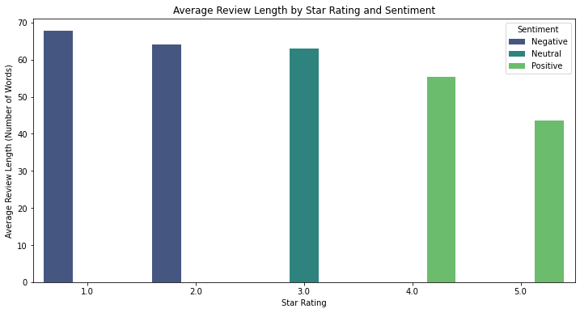

```python
# Add a column for the review length
df['review_length'] = df['cleaned_text'].apply(lambda x: len(x.split()))

# Calculate average review length for each star rating and sentiment
avg_length = df.groupby(['stars', 'Sentiment'])['review_length'].mean().reset_index()

# Plot the findings
plt.figure(figsize=(12, 6))
sns.barplot(x='stars', y='review_length', hue='Sentiment', data=avg_length, palette='viridis')
plt.title("Average Review Length by Star Rating and Sentiment")
plt.xlabel("Star Rating")
plt.ylabel("Average Review Length (Number of Words)")
plt.legend(title='Sentiment')
plt.show()
```

# explain your rationale for the tuning approaches used each iteration

Here are three key tuning strategies:

TF-IDF or Embeddings (Word2Vec, BERT): Switch to TF-IDF or use word embeddings to better capture feature importance and context, potentially improving accuracy by 2-5%.

Random Search for Hyperparameter Tuning: Use random search over a broader range of hyperparameters to efficiently find optimal settings, boosting F1 score by 2-3%.

Class Imbalance Handling (SMOTE, Class Weights): Address class imbalance using SMOTE or class weights, improving F1 scores for the minority class by 5-10%.

Assistance was sought from ChatGPT in refining the approach.